## Building a Document Scanner using OpenCV

# 1. Import the needed packages

First of all, we need to import the packages needed for our project. We will use:

1. NumPy - The fundamental package for scrientific computing with Python
2. Matplotlib - A comprehensive library for creating static, animated and interactive visualizations in Python.
3. OpenCV - OpenCV or cv2 provides a real-time optimized Computer Vision library, tools, and hardware. It also supports model execution for Machine Learning (ML) and Artificial Intelligence.

```python
import cv2
import numpy as np
import matplotlib.pyplot as plt
from skimage.filters import threshold_local
%matplotlib inline
import imutils
```

GThen, we open an image from a file. This image will be our raw input (a photo of a document taken on a certain background - e.g. an A4 document sitting on a table)

```python
InputIm_FileName = "img12.jpg"
img = cv2.imread(InputIm_FileName, cv2.IMREAD_COLOR)
```

```python
# Resize image to workable size
dim_limit = 1080
max_dim = max(img.shape)
if max_dim > dim_limit:
    resize_scale = dim_limit / max_dim
    img = cv2.resize(img, None, fx=resize_scale, fy=resize_scale)

# Making Copy of original image.
orig_img = img.copy()
```

We display the image to make sure that the input is successfully read.

[figure not shown]

```python
plt.figure(figsize = (10,7))
plt.imshow(img[:,:,::-1])
plt.title('The original unedited image')
plt.show()
```

# 2. Morphological operations

**`morphologyEx()`** perform advanced morphological transformations using an erosion and dilation as basic operations.

### Function Syntax

```
dst = cv2.morphologyEx( src, op, kernel[, dst[, anchor[, iterations[, borderType[, borderValue]]]]] )
```

`dst`: Destination image of the same size and type as source image.

1. `src` Source image. The number of channels can be arbitrary. The depth should be one of CV_8U, CV_16U, CV_16S, CV_32F or CV_64F.
2. `op` Type of a morphological operation, see [MorphTypes](https://docs.opencv.org/4.5.2/d4/d86/group__imgproc__filter.html#ga7be549266bad7b2e6a04db49827f9f32).
3. `kernel` Structuring element. It can be created using [getStructuringElement](https://docs.opencv.org/4.5.2/d4/d86/group__imgproc__filter.html#gac342a1bb6eabf6f55c803b09268e36dc).
4. `iterations` Number of times erosion and dilation are applied.

### OpenCV Documentation

[**`morphologyEx()`**](https://docs.opencv.org/4.5.2/d4/d86/group__imgproc__filter.html#ga67493776e3ad1a3df63883829375201f)  
[**`dilute()`**](https://docs.opencv.org/4.5.2/d4/d86/group__imgproc__filter.html#ga4ff0f3318642c4f469d0e11f242f3b6c)  
[**`erode()`**](https://docs.opencv.org/4.5.2/d4/d86/group__imgproc__filter.html#gaeb1e0c1033e3f6b891a25d0511362aeb)

## MORPH_CLOSE

a closing operation

```
𝚍𝚜𝚝=close(𝚜𝚛𝚌,𝚎𝚕𝚎𝚖𝚎𝚗𝚝)=erode(dilate(𝚜𝚛𝚌,𝚎𝚕𝚎𝚖𝚎𝚗𝚝))
```

We will use a closing morphological operation, in order to remove the text from our document, so the data written on the document doesn't affect the corner detection performed in the next step

```python
# Repeated Closing operation to remove text from the document.
kernel = np.ones((5,5),np.uint8)
img = cv2.morphologyEx(img, cv2.MORPH_CLOSE, kernel, iterations= 3)
```

Display the result:

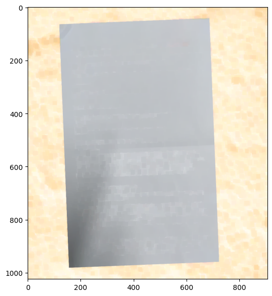

```python
plt.figure(figsize = (10,7))
plt.imshow(img[:,:,::-1])
plt.show()
```

The next block of code is responsible with the background removal of the document.

1. Initial Setup: The code prepares a blank canvas (mask) the same size as the image, defines a region of interest (ROI) in the image, and initializes models for the background and foreground.
2. Background Removal: It runs the GrabCut algorithm, which separates the object from the background by iteratively learning and updating which parts of the image are likely to be the object (foreground) and which parts are likely the background.

Final Result: After running GrabCut, it generates a mask that distinguishes the object from the background. Then, it applies this mask to the original image, effectively removing the background and leaving you with an image where only the object of interest remains.

```python
mask = np.zeros(img.shape[:2],np.uint8)
  bgdModel = np.zeros((1,65),np.float64)
  fgdModel = np.zeros((1,65),np.float64)
  rect = (20,20,img.shape[1]-20,img.shape[0]-20)
  cv2.grabCut(img,mask,rect,bgdModel,fgdModel,5,cv2.GC_INIT_WITH_RECT)
  mask2 = np.where((mask==2)|(mask==0),0,1).astype('uint8')
  img = img*mask2[:,:,np.newaxis]
```

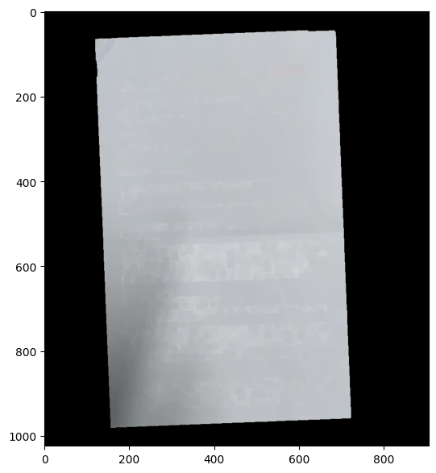

```python
plt.figure(figsize = (10,7))
plt.imshow(img[:,:,::-1])
plt.show()
```

# 3. Canny Edge Detection. Getting Countours for the detected edges.

## Canny Edge Detector

**`Canny()`** finds edges in the input image and marks them in the output map edges using the Canny algorithm.

### Function Syntax

```
edges = cv2.Canny( image, threshold1, threshold2[, edges[, apertureSize[, L2gradient]]] )
```

`edges`: output edge map; single channels 8-bit image, which has the same size as image. The function has **3 required arguments**:

1. `image` 8-bit input image.
2. `threshold1` first threshold for the hysteresis procedure.
3. `threshold2` second threshold for the hysteresis procedure.

### OpenCV Documentation

[**`cv2.Canny()`**](https://docs.opencv.org/4.5.2/dd/d1a/group__imgproc__feature.html#ga04723e007ed888ddf11d9ba04e2232de)

The below code is responsible with the following tasks:

1. Converts the input color image to grayscale.
2. Applies Gaussian blurring to reduce noise.
3. Detects edges using the Canny edge detection method.
4. Enhances the detected edges by dilating them.
5. Displays the processed image with the edges highlighted.

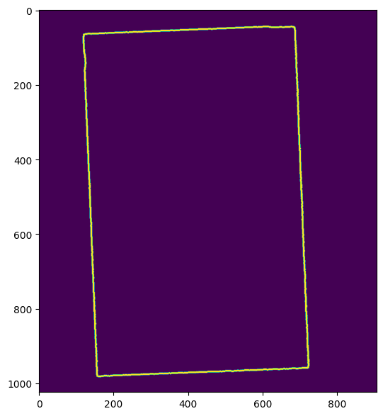

```python
gray = cv2.cvtColor(img, cv2.COLOR_BGR2GRAY)
gray = cv2.GaussianBlur(gray, (11, 11), 0)
# Edge Detection.
canny = cv2.Canny(gray, 100, 200)
canny = cv2.dilate(canny, cv2.getStructuringElement(cv2.MORPH_ELLIPSE,(5,5)))
plt.figure(figsize = (10,7))
plt.imshow(canny)
plt.show()
```

## Contour Detection

**`findContours()`** finds contours in a binary image.

### Function Syntax

```
contours, hierarchy = cv2.findContours( image, mode, method[, contours[, hierarchy[, offset]]] )
```

`contours`: Detected contours. Each contour is stored as a vector of points. `hierarchy`: Optional output vector, containing information about the image topology. It has as many elements as the number of contours. For each i-th contour contours[i], the elements hierarchy[i][0] , hierarchy[i][1] , hierarchy[i][2] , and hierarchy[i][3] are set to 0-based indices in contours of the next and previous contours at the same hierarchical level, the first child contour and the parent contour, respectively. If for the contour i there are no next, previous, parent, or nested contours, the corresponding elements of hierarchy[i] will be negative.

The function has **3 required arguments** and 3 optional:

1. `image` Source, an 8-bit single-channel image.
2. `mode` Contour retrieval mode, see [RetrievalModes](https://docs.opencv.org/4.5.2/d3/dc0/group__imgproc__shape.html#ga819779b9857cc2f8601e6526a3a5bc71).
3. `method` Contour approximation method, see [ContourApproximationModes](https://docs.opencv.org/4.5.2/d3/dc0/group__imgproc__shape.html#ga4303f45752694956374734a03c54d5ff).

### OpenCV Documentation

[**`cv2.findContours()`**](https://docs.opencv.org/4.5.2/d3/dc0/group__imgproc__shape.html#ga17ed9f5d79ae97bd4c7cf18403e1689a)

## Draw Contour

**`drawContours()`** draws contours outlines or filled contours.

### Function Syntax

```
cv2.drawContours( image, contours, contourIdx, color[, thickness[, lineType[, hierarchy[, maxLevel[, offset]]]]] )
```

The function has **4 required arguments** and 5 optional:

1. `image` Destination image.
2. `contours` All the input contours. Each contour is stored as a point vector.
3. `contourIdx` Parameter indicating a contour to draw. If it is negative, all the contours are drawn.
4. `color` Color of the contours.
5. `thickness` Thickness of lines the contours are drawn with. If it is negative (for example, thickness=FILLED ), the contour interiors are drawn.

### OpenCV Documentation

[**`cv2.drawContours()`**](https://docs.opencv.org/4.5.2/d6/d6e/group__imgproc__draw.html#ga746c0625f1781f1ffc9056259103edbc)

```python
# Blank canvas.
con = np.zeros_like(img)
# Finding contours for the detected edges.
contours, hierarchy = cv2.findContours(canny, cv2.RETR_LIST, cv2.CHAIN_APPROX_NONE)
# Keeping only the largest detected contour.
page = sorted(contours, key=cv2.contourArea, reverse=True)[:5]
con = cv2.drawContours(con, page, -1, (0, 255, 255), 3)
```

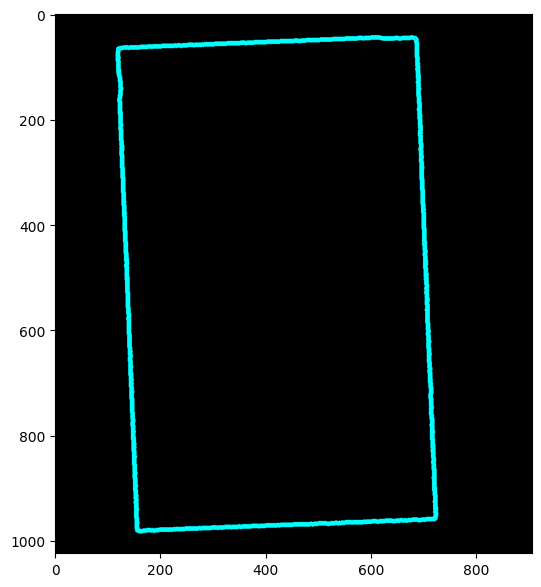

```python
plt.figure(figsize = (10,7))
plt.imshow(con)
plt.show()
```

# Corner Detection using Douglas-Peucker algorithm

## Contour Perimeter

**`arcLength()`** calculates a contour perimeter or a curve length.

### Function Syntax

```
retval  =   cv.arcLength( curve, closed )
```

The function has **2 required arguments**:

1. `curve` Input vector of 2D points, stored in std::vector or [Mat](https://docs.opencv.org/4.5.2/d3/d63/classcv_1_1Mat.html).
2. `closed` Flag indicating whether the curve is closed or not.

### OpenCV Documentation

[**`cv2.arcLength()`**](https://docs.opencv.org/4.5.2/d3/dc0/group__imgproc__shape.html#ga8d26483c636be6b35c3ec6335798a47c)

## Contour Approximation

**`approxPolyDP()`** approximates a polygonal curve(s) with the specified precision.

### Function Syntax

```
approxCurve = cv2.approxPolyDP( curve, epsilon, closed[, approxCurve] )
```

`approxCurve` Result of the approximation. The type should match the type of the input curve.

The function has **3 required arguments**:

1. `curve` Input vector of 2D points, stored in std::vector or [Mat](https://docs.opencv.org/4.5.2/d3/d63/classcv_1_1Mat.html).
2. `epsilon` Parameter specifying the approximation accuracy. This is the maximum distance between the original curve and its approximation.
3. `closed` If true, the approximated curve is closed (its first and last vertices are connected). Otherwise, it is not closed.

### OpenCV Documentation

[**`cv2.approxPolyDP()`**](https://docs.opencv.org/4.5.2/d3/dc0/group__imgproc__shape.html#ga0012a5fdaea70b8a9970165d98722b4c)

### Detected contour is approximated to a quadrilateral, giving the 4 corners.

The below code defines a function order_points(pts) that takes a list of four points as input. The function's purpose is to rearrange these four points in a specific order: top-left, top-right, bottom-right, bottom-left. Here's a brief summary of what the code does:

1. Creates an empty array rect to store the ordered points. It's initialized as a 4x2 NumPy array with a data type of float32.
2. Calculates the sum of x and y coordinates for each point in pts. The point with the smallest sum is considered the top-left point, and the point with the largest sum is considered the bottom-right point.
3. Calculates the difference between x and y coordinates for each point in pts. The point with the smallest difference is considered the top-right point, and the point with the largest difference is considered the bottom-left point.
4. Updates the rect array with the identified points in the specified order (top-left, top-right, bottom-right, bottom-left).

Converts the coordinates in rect to integer values and then converts them to a list.

Returns the ordered coordinates as a list.

In summary, this function takes a list of points and reorders them in a specific way, ensuring that the top-left, top-right, bottom-right, and bottom-left points are correctly identified and returned as a list of ordered coordinates.

```python
def order_points(pts):
	'''Rearrange coordinates to order:
       top-left, top-right, bottom-right, bottom-left'''
	rect = np.zeros((4, 2), dtype='float32')
	pts = np.array(pts)
	s = pts.sum(axis=1)
	# Top-left point will have the smallest sum.
	rect[0] = pts[np.argmin(s)]
    # Bottom-right point will have the largest sum.
	rect[2] = pts[np.argmax(s)]

	diff = np.diff(pts, axis=1)
    # Top-right point will have the smallest difference.
	rect[1] = pts[np.argmin(diff)]
    # Bottom-left will have the largest difference.
	rect[3] = pts[np.argmax(diff)]
	# Return the ordered coordinates.
	return rect.astype('int').tolist()
```

```
[[118, 64], [686, 44], [724, 959], [154, 982]]
```

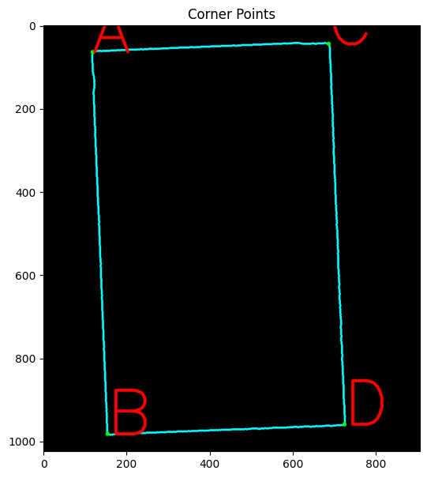

```python
# Blank canvas.
con = np.zeros_like(img)
# Loop over the contours.
for c in page:
	# Approximate the contour.
	epsilon = 0.02 * cv2.arcLength(c, True)
	corners = cv2.approxPolyDP(c, epsilon, True)
	# If our approximated contour has four points
	if len(corners) == 4:
		break
cv2.drawContours(con, c, -1, (0, 255, 255), 3)
cv2.drawContours(con, corners, -1, (0, 255, 0), 10)
# Sorting the corners and converting them to desired shape.
corners = sorted(np.concatenate(corners).tolist())

# Displaying the corners.
for index, c in enumerate(corners):
    character = chr(65 + index)
    cv2.putText(con, character, tuple(c), cv2.FONT_HERSHEY_SIMPLEX, 5, (255, 0, 0), 5, cv2.LINE_AA)

# Rearranging the order of the corner points.
corners = order_points(corners)

print(corners)

plt.figure(figsize = (10,7))
plt.imshow(con)
plt.title('Corner Points')
plt.show()
```

# Finding Destination Co-ordinates

1. Deconstructs the corners variable (which should contain the ordered corner points) into four separate points: tl (top-left), tr (top-right), br (bottom-right), and bl (bottom-left).
2. Calculates the maximum width of the object by finding the distance between the bottom-right and bottom-left corners and the distance between the top-right and top-left corners. It then takes the larger of the two widths as maxWidth.
3. Calculates the maximum height of the object by finding the distance between the top-right and bottom-right corners and the distance between the top-left and bottom-left corners. It then takes the larger of the two heights as maxHeight.
4. Defines a list called destination_corners that contains the coordinates of the corners in a specific order, effectively defining the desired shape's destination coordinates. These coordinates appear to be in a specific format: [top-left, top-right, bottom-right, bottom-left].
5. Prints the destination_corners, which should now represent the ordered destination coordinates of the object.

```python
(tl, tr, br, bl) = corners
# Finding the maximum width.
widthA = np.sqrt(((br[0] - bl[0]) ** 2) + ((br[1] - bl[1]) ** 2))
widthB = np.sqrt(((tr[0] - tl[0]) ** 2) + ((tr[1] - tl[1]) ** 2))
maxWidth = max(int(widthA), int(widthB))

# Finding the maximum height.
heightA = np.sqrt(((tr[0] - br[0]) ** 2) + ((tr[1] - br[1]) ** 2))
heightB = np.sqrt(((tl[0] - bl[0]) ** 2) + ((tl[1] - bl[1]) ** 2))
maxHeight = max(int(heightA), int(heightB))
# Final destination co-ordinates.
destination_corners = [
		[0, 0],
		[maxWidth, 0],
		[maxWidth, maxHeight],
		[0, maxHeight]]
print(destination_corners)
```

```
[[0, 0], [570, 0], [570, 918], [0, 918]]
```

# Homography and Perspective Transform

## Homography

### Function Syntax

```
retval, mask = cv2.findHomography( srcPoints, dstPoints[, method[, ransacReprojThreshold[, mask[, maxIters[, confidence]]]]] )
```

The function has **2 required arguments** and 5 optional flags:

4. `ransacReprojThreshold` Maximum allowed reprojection error to treat a point pair as an inlier (used in the RANSAC and RHO methods only). That is, if  
   `||` `dstPoints`<sub>`i`</sub>-`convertPointsHomogeneous`(`H*srcPoints`<sub>`i`</sub>)`||`<sub>`2`</sub>>`ransacReprojThreshold`  
   then the point i is considered as an outlier. If srcPoints and dstPoints are measured in pixels, it usually makes sense to set this parameter somewhere in the range of 1 to 10.
5. `mask` Optional output mask set by a robust method ( RANSAC or LMeDS ). Note that the input mask values are ignored.
6. `maxIters` The maximum number of RANSAC iterations.
7. `confidence` Confidence level, between 0 and 1.

### OpenCV Documentation

[**`cv2.warpPerspective()`**](https://docs.opencv.org/4.5.2/da/d54/group__imgproc__transform.html#gaf73673a7e8e18ec6963e3774e6a94b87)

## Perspective Transform

**`warpPerspective()`** applies a perspective transformation to an image.

### Function Syntax

```
dst = cv2.warpPerspective( src, M, dsize[, dst[, flags[, borderMode[, borderValue]]]] )
```

`dst` output image of the same size and type as src. The function has **3 required arguments** and 3 optional flags:

1. `src` input image.
2. `M` 3×3 transformation matrix.
3. `dsize` size of the output image.
4. `flags` combination of interpolation methods INTER_LINEAR or INTER_NEAREST and the optional flag WARP_INVERSE_MAP, that sets M as the inverse transformation ( 𝚍𝚜𝚝→𝚜𝚛𝚌 ).
5. `borderMode` pixel extrapolation method BORDER_CONSTANT or BORDER_REPLICATE
6. `borderValue` value used in case of a constant border; by default, it equals 0.

### OpenCV Documentation

[**`cv2.warpPerspective()`**](https://docs.opencv.org/4.5.2/da/d54/group__imgproc__transform.html#gaf73673a7e8e18ec6963e3774e6a94b87)

```python
# Getting the homography.
homography = cv2.getPerspectiveTransform(np.float32(corners), np.float32(destination_corners))
# Perspective transform using homography.
warped = cv2.warpPerspective(orig_img, np.float32(homography), (maxWidth, maxHeight), flags=cv2.INTER_LINEAR)

warped = cv2.cvtColor(warped, cv2.COLOR_BGR2GRAY)
T = threshold_local(warped, 11, offset = 10, method = "gaussian")
warped = (warped > T).astype("uint8") * 255
```

Display the final results:

[figure not shown]

```python
plt.figure(figsize=[20,10]);
plt.subplot(121); plt.imshow(orig_img[:,:,::-1]); plt.axis('off'); plt.title("Original image")
plt.subplot(122); plt.imshow(cv2.cvtColor(imutils.resize(warped, height=650), cv2.COLOR_BGR2RGB)); plt.title("Scanned image")
```

```python
from google.colab import drive
drive.mount('/content/drive', force_remount=True)
```

```python
%%shell
jupyter nbconvert --to html '/content/drive/MyDrive/Colab Notebooks/DDR_PNI_Project.ipynb'
```

```
[NbConvertApp] Converting notebook /content/drive/MyDrive/Colab Notebooks/DDR_PNI_Project.ipynb to html
[NbConvertApp] Writing 3687384 bytes to /content/drive/MyDrive/Colab Notebooks/DDR_PNI_Project.html
```